# Analysis of Key Drivers for Agricultural Crop Yield Using R and SQL

Jen Jones

November 04, 2025

## Introduction

My goal for this project is to analyze an agricultural dataset to identify key drivers of crop yield and resource management. This analysis combines my foundational knowledge from an A.S. in Agricultural Business with new technical skills in R and SQL for data analysis.

The dataset contains farm-level information on crop types, farm area, irrigation, resource usage (fertilizer, pesticide, water), and final crop yield. I will be cleaning and analyzing this data to answer key business questions.

## Setup and Data Preparation

First, we must load the necessary R packages. I use **`tidyverse`** for data manipulation (`dplyr`) and visualization (`ggplot2`), **`sqldf`** to demonstrate running SQL queries, and the **`knitr::kable()`** function to create the professionally formatted tables seen throughout this report.

### Data Loading and Cleaning

The raw `.csv` file has column names with special characters (e.g., `Yield(tons)`) that are difficult to work with in R. I will load the data and then use `dplyr::rename` to create clean and consistent column names for analysis.

### Data Cleaning

```r
# 1. Read the CSV, telling it not to check names
agri_data_raw <- read.csv("agriculture_dataset.csv", check.names = FALSE)

# 2. Rename columns to be valid R variable names (no spaces or '()')
agri_data <- agri_data_raw %>%
  rename(
    Farm_Area_acres = `Farm_Area(acres)`,
    Fertilizer_Used_tons = `Fertilizer_Used(tons)`,
    Pesticide_Used_kg = `Pesticide_Used(kg)`,
    Yield_tons = `Yield(tons)`,
    Water_Usage_m3 = `Water_Usage(cubic meters)`
  )

# 3. Convert character columns to factors for modeling
agri_data <- agri_data %>%
  mutate(across(where(is.character), as.factor))


# 4. Display the first 6 rows to confirm successful cleaning
knitr::kable(head(agri_data), caption = "A Preview of the Cleaned Data")
```

A Preview of the Cleaned Data

| Farm_ID | Crop_Type | Farm_Area_acres | Irrigation_Type | Fertilizer_Used_tons | Pesticide_Used_kg | Yield_tons | Soil_Type | Season | Water_Usage_m3 |
| --- | --- | --- | --- | --- | --- | --- | --- | --- | --- |
| F001 | Cotton | 329.40 | Sprinkler | 8.14 | 2.21 | 14.44 | Loamy | Kharif | 76648.20 |
| F002 | Carrot | 18.67 | Manual | 4.77 | 4.36 | 42.91 | Peaty | Kharif | 68725.54 |
| F003 | Sugarcane | 306.03 | Flood | 2.91 | 0.56 | 33.44 | Silty | Kharif | 75538.56 |
| F004 | Tomato | 380.21 | Rain-fed | 3.32 | 4.35 | 34.08 | Silty | Zaid | 45401.23 |
| F005 | Tomato | 135.56 | Sprinkler | 8.33 | 4.48 | 43.28 | Clay | Zaid | 93718.69 |
| F006 | Sugarcane | 12.50 | Sprinkler | 6.42 | 2.25 | 38.18 | Loamy | Zaid | 46487.98 |

## Analysis: R for Visualization

To showcase my R skills, I’ll use `dplyr` to summarize data and `ggplot2` to visualize it.

### Question 1: Which irrigation type results in the highest average yield?

This is a key question for farm efficiency. Understanding the impact of irrigation on yield can guide decisions on infrastructure investment.

```r
# 1. Summarise data: Calculate mean yield per irrigation type
yield_by_irrigation <- agri_data %>%
  group_by(Irrigation_Type) %>%
  summarise(Average_Yield = mean(Yield_tons, na.rm = TRUE)) %>%
  arrange(desc(Average_Yield))

# 2. Display the summary table
knitr::kable(
  yield_by_irrigation,
  caption = "Average Yield by Irrigation Type",
  digits = 1  # Round to 1 decimal place
)
```

Average Yield by Irrigation Type

| Irrigation_Type | Average_Yield |
| --- | --- |
| Manual | 34.2 |
| Rain-fed | 32.0 |
| Sprinkler | 27.9 |
| Drip | 26.8 |
| Flood | 20.9 |

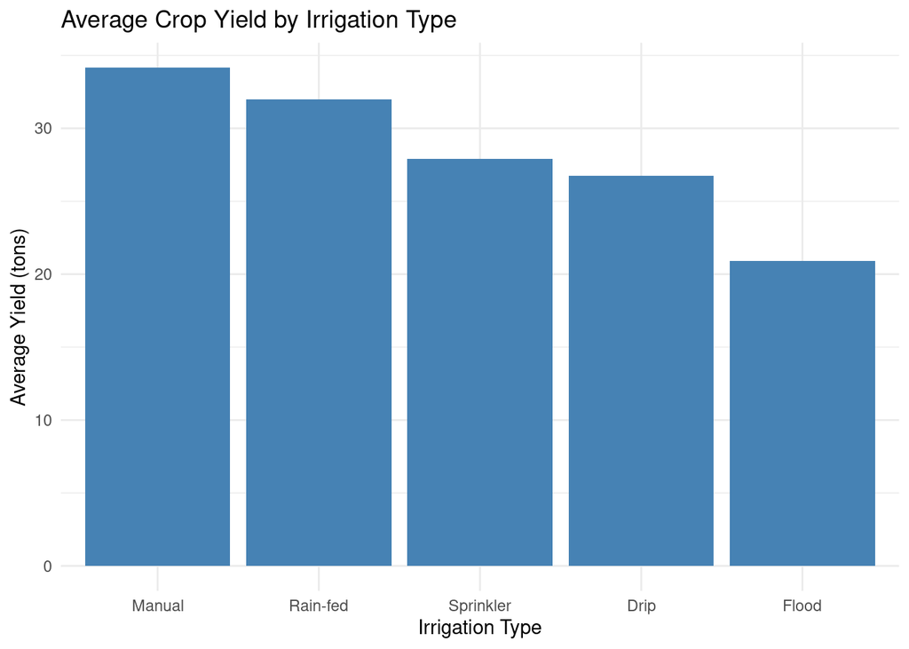

```r
# 3. Visualize the findings for easy comparison
ggplot(yield_by_irrigation, aes(x = reorder(Irrigation_Type, -Average_Yield), y = Average_Yield)) +
    geom_bar(stat = "identity", fill = "steelblue") +
    labs(
      title = "Average Crop Yield by Irrigation Type",
      x = "Irrigation Type",
      y = "Average Yield (tons)"
    ) +
    theme_minimal()
```

**Finding:** The chart and table clearly show that **Manual** irrigation is associated with the highest average yield. Conversely, **Flood** irrigation is the least effective method.

## Analysis: SQL for Data Querying

To demonstrate skill in SQL, I will answer our next question using the `sqldf` package. This allows me to query the `agri_data` data frame as if it were a SQL database, showcasing my versatility as an analyst.

### Question 2: What is the average fertilizer and water usage for each crop?

Resource management is critical in agriculture. This query will help identify which crops are the most resource-intensive.

### 1. Write and run the SQL query

```r
# This query selects the crop type and calculates the average
# fertilizer and water usage.
crop_resource_summary <- sqldf("
  SELECT
    Crop_Type,
    AVG(Fertilizer_Used_tons) AS Avg_Fertilizer,
    AVG(Water_Usage_m3) AS Avg_Water_Usage
  FROM
    agri_data
  GROUP BY
    Crop_Type
  ORDER BY
    Avg_Fertilizer DESC")
```

### 2. Print the results from the SQL query

```r
crop_resource_summary %>%
  knitr::kable(
    digits = 2,
    caption = "Resource Use by Crop Type (from SQL):"
  )
```

Resource Use by Crop Type (from SQL):

| Crop_Type | Avg_Fertilizer | Avg_Water_Usage |
| --- | --- | --- |
| Potato | 8.02 | 57033.57 |
| Rice | 5.74 | 46761.41 |
| Tomato | 5.51 | 73479.36 |
| Carrot | 5.22 | 77143.49 |
| Wheat | 4.96 | 44460.78 |
| Barley | 4.88 | 53594.63 |
| Cotton | 4.73 | 52991.42 |
| Sugarcane | 3.70 | 55664.90 |
| Soybean | 3.68 | 57875.38 |
| Maize | 2.19 | 44392.15 |

**Finding:** The resulting table shows the average fertilizer and water use for each crop, sorted by fertilizer consumption. This could be used by farm managers to forecast costs or identify high-resource crops for efficiency improvements.

## Modeling: Identifying Key Drivers of Yield

### Model 1: Initial Linear Hypothesis

I’ll start with a simple linear regression (`lm`) to test if yield is driven by our three most obvious inputs: fertilizer, water, and irrigation.

```r
# Model 1: Test only Fertilizer, Water, and Irrigation
simple_model <- lm(Yield_tons ~ Fertilizer_Used_tons + Water_Usage_m3 + Irrigation_Type,
                   data = agri_data)

summary(simple_model)
```

```
##
## Call:
## lm(formula = Yield_tons ~ Fertilizer_Used_tons + Water_Usage_m3 +
##     Irrigation_Type, data = agri_data)
##
## Residuals:
##     Min      1Q  Median      3Q     Max
## -21.100 -10.170   2.580   9.486  24.719
##
## Coefficients:
##                            Estimate Std. Error t value Pr(>|t|)
## (Intercept)               1.931e+01  6.208e+00   3.111  0.00331 **
## Fertilizer_Used_tons      5.425e-01  6.989e-01   0.776  0.44192
## Water_Usage_m3            8.866e-05  7.064e-05   1.255  0.21622
## Irrigation_TypeFlood     -7.192e+00  5.059e+00  -1.422  0.16233
## Irrigation_TypeManual     7.876e+00  6.404e+00   1.230  0.22546
## Irrigation_TypeRain-fed   6.132e+00  6.039e+00   1.015  0.31567
## Irrigation_TypeSprinkler  6.798e-01  5.537e+00   0.123  0.90286
## ---
## Signif. codes:  0 '***' 0.001 '**' 0.01 '*' 0.05 '.' 0.1 ' ' 1
##
## Residual standard error: 13.1 on 43 degrees of freedom
## Multiple R-squared:  0.1539, Adjusted R-squared:  0.03586
## F-statistic: 1.304 on 6 and 43 DF,  p-value: 0.2761
```

**Conclusion:** We can confidently say that fertilizer, water usage, and irrigation type are **not** the primary drivers of yield *when viewed in isolation*.

### Model 2: Comprehensive Linear Model & Diagnosis

Since Model 1 failed, my next step is to build a comprehensive model that includes **all** available factors. This will show if a linear model can work at all.

```r
# Model 2: A comprehensive model to find the real drivers.
# The formula `Yield_tons ~ . - Farm_ID` predicts yield using all
# other columns, while removing the Farm_ID (which is just an identifier).
comprehensive_model <- lm(Yield_tons ~ . - Farm_ID, data = agri_data)

summary(comprehensive_model)
```

```
##
## Call:
## lm(formula = Yield_tons ~ . - Farm_ID, data = agri_data)
##
## Residuals:
##      Min       1Q   Median       3Q      Max
## -24.5495  -6.3395  -0.5672   8.6146  17.6886
##
## Coefficients:
##                            Estimate Std. Error t value Pr(>|t|)
## (Intercept)               7.554e+00  1.424e+01   0.530    0.600
## Crop_TypeCarrot           9.841e+00  1.141e+01   0.862    0.396
## Crop_TypeCotton          -1.023e+01  8.415e+00  -1.215    0.235
## Crop_TypeMaize           -8.445e+00  1.236e+01  -0.683    0.501
## Crop_TypePotato          -9.827e+00  1.032e+01  -0.952    0.350
## Crop_TypeRice            -7.737e+00  9.343e+00  -0.828    0.415
## Crop_TypeSoybean         -2.372e+00  1.064e+01  -0.223    0.825
## Crop_TypeSugarcane        5.226e+00  9.169e+00   0.570    0.574
## Crop_TypeTomato           1.549e+00  1.035e+01   0.150    0.882
## Crop_TypeWheat           -8.384e-02  9.987e+00  -0.008    0.993
## Farm_Area_acres           2.485e-02  2.016e-02   1.232    0.229
## Irrigation_TypeFlood     -8.845e+00  7.906e+00  -1.119    0.273
## Irrigation_TypeManual     9.316e+00  9.613e+00   0.969    0.341
## Irrigation_TypeRain-fed   1.006e+01  7.790e+00   1.292    0.208
## Irrigation_TypeSprinkler  1.999e+00  7.625e+00   0.262    0.795
## Fertilizer_Used_tons      1.460e+00  1.064e+00   1.372    0.182
## Pesticide_Used_kg        -2.954e-01  1.721e+00  -0.172    0.865
## Soil_TypeLoamy           -2.932e+00  7.421e+00  -0.395    0.696
## Soil_TypePeaty           -7.233e+00  1.027e+01  -0.705    0.487
## Soil_TypeSandy            1.053e+01  7.641e+00   1.378    0.180
## Soil_TypeSilty            4.155e+00  7.297e+00   0.569    0.574
## SeasonRabi                4.085e+00  8.408e+00   0.486    0.631
## SeasonZaid                3.842e+00  6.066e+00   0.633    0.532
## Water_Usage_m3            6.676e-05  1.155e-04   0.578    0.568
##
## Residual standard error: 14.18 on 26 degrees of freedom
## Multiple R-squared:  0.4012, Adjusted R-squared:  -0.1286
## F-statistic: 0.7573 on 23 and 26 DF,  p-value: 0.7481
```

**Finding 2:** This model is an even **worse fit** than the simple one, which provides a critical diagnostic insight.

- **Adjusted R-squared:** The value is -0.129. A negative R-squared means the model is performing *worse* than simply guessing the average.
- **Conclusion:** This is a classic sign of **overfitting**. We have too many variables for a small dataset, and the simple, linear `lm` function cannot find a meaningful pattern. This is a key analytical conclusion: **a linear model is the wrong tool for this dataset.**

### Model 3: Pivoting to a Random Forest

Based on the failure of our linear models, I pivoted to a **Random Forest**. This is a powerful machine-learning model that is excellent at finding complex, non-linear patterns and is not easily confused by a large number of variables.

```r
# Set a seed for reproducibility
set.seed(42)

# Build the Random Forest model
# We must remove 'Farm_ID' and tell the model to ignore any rows with NAs
rf_model <- randomForest(Yield_tons ~ . - Farm_ID,
                         data = agri_data,
                         na.action = na.omit) # Omit rows with NAs to ensure the model runs

# --- 1. Print the Model Summary ---
# This text output shows the model's R-squared
print(rf_model)
```

```
##
## Call:
##  randomForest(formula = Yield_tons ~ . - Farm_ID, data = agri_data,      na.action = na.omit)
##                Type of random forest: regression
##                      Number of trees: 500
## No. of variables tried at each split: 2
##
##           Mean of squared residuals: 216.5863
##                     % Var explained: -24.08
```

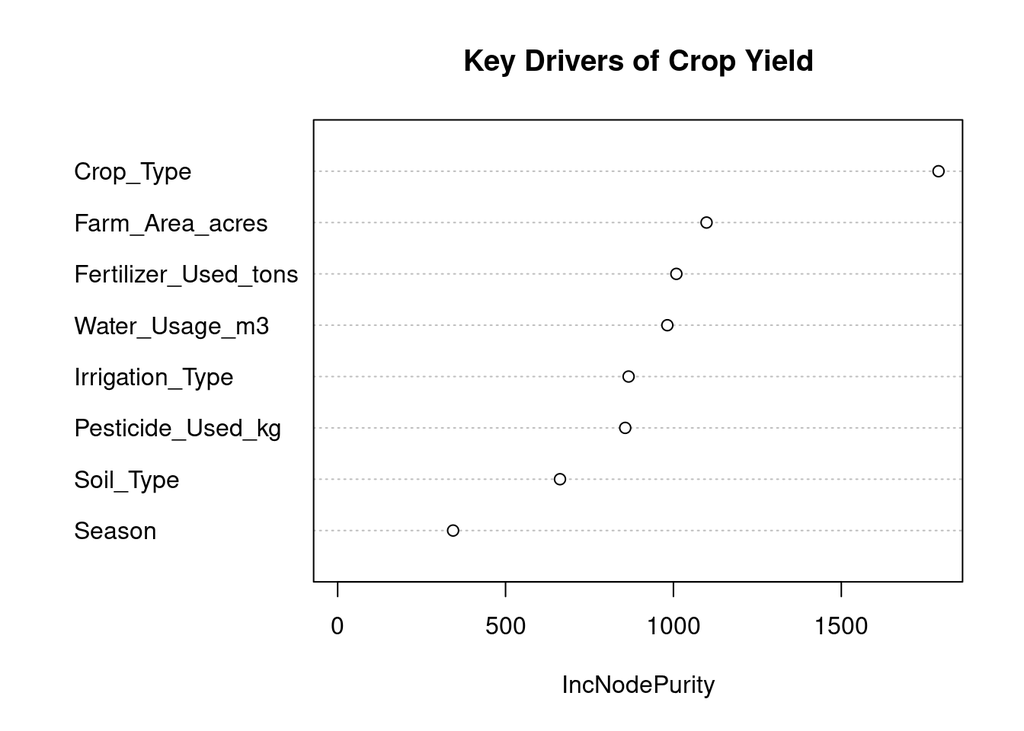

```r
# --- 2. Create the Importance Plot ---
# This is a great visual for a quick summary
varImpPlot(rf_model, main = "Key Drivers of Crop Yield")
```

```r
# --- 3. Create the kable() Importance Table ---
# This presents the same data in a professional table,
# which is easier to read precisely.
importance_scores <- as.data.frame(importance(rf_model))
importance_scores$Variable <- rownames(importance_scores)

# Use dplyr to select, arrange, and present the data
importance_table <- importance_scores %>%
  select(Variable, IncNodePurity) %>%
  arrange(desc(IncNodePurity))

# Now, use kable() to make the table
knitr::kable(
  importance_table,
  digits = 2, # Round to 2 decimal places
  caption = "Ranked Table of Variable Importance (IncNodePurity)"
)
```

Ranked Table of Variable Importance (IncNodePurity)

|  | Variable | IncNodePurity |
| --- | --- | --- |
| Crop_Type | Crop_Type | 1789.51 |
| Farm_Area_acres | Farm_Area_acres | 1098.62 |
| Fertilizer_Used_tons | Fertilizer_Used_tons | 1008.74 |
| Water_Usage_m3 | Water_Usage_m3 | 981.86 |
| Irrigation_Type | Irrigation_Type | 866.48 |
| Pesticide_Used_kg | Pesticide_Used_kg | 856.44 |
| Soil_Type | Soil_Type | 662.17 |
| Season | Season | 343.78 |

## Conclusion

This analysis demonstrates a complete workflow for an agricultural data project, moving from data cleaning to visualization, SQL querying, and advanced predictive modeling.

This project successfully showcases how to use R (Tidyverse) and SQL to clean, analyze, and derive actionable insights from agricultural data.